# Project 2 (EAS502 : Intro Prob Theory)

Rishi Shanthan Bhagavatham

05-02-2024

**Submitted to : Dr. Vochita Mihai**

**I. For all the Question, please solve the problems using a code in R. Save the document according with the instructions provided in the attached document.**

## Question 1

1). You are taking a 15-question multiple choice quiz and each question has 5 options (a, b, c, d, e) and you randomly guess every question.

1. How many questions do you expect to answer correct on average?
2. What is the probability that you get every question correct?
3. What is the probability that you get every question incorrect?
4. How many questions does one need to answer correctly in order score exactly a 60%?
5. If a grade of 60% or lower is considered failing, then what is the probability of you failing?
6. If you need a grade of 80% or higher on this quiz to maintain a passing grade, what is the probability of you maintaining that passing grade?

```r
# Q1 a
q1a_answer <- 15 * (1 / 5)
cat("Number of questions we expect to answer correct on average:",q1a_answer)
```

```
## Number of questions we expect to answer correct on average: 3
```

```r
# Q1 b
q1b_answer <- (1 / 5)^15
cat("probability that we get every question correct:",q1b_answer)
```

```
## probability that we get every question correct: 3.2768e-11
```

```r
cat("Probability that we get every question correct (Using floor function):",floor(q1b_answer))
```

```
## Probability that we get every question correct (Using floor function): 0
```

```r
# Q1 c
q1c_answer <- ((5 - 1)/5)^15
q1c_answer * 100
```

```
## [1] 3.518437
```

```r
cat("Probability that you get every question incorrect:",q1c_answer)
```

```
## Probability that you get every question incorrect: 0.03518437
```

```r
# Q1 d
q1d_answer <- 15 * 0.60
cat("Questions does one need to answer correctly in order score exactly a 60% :",q1d_answer)
```

```
## Questions does one need to answer correctly in order score exactly a 60% : 9
```

```r
# Q1 e
q1e_answer <- pbinom(q = q1d_answer, size = 15, prob = 0.2)
q1e_answer
```

```
## [1] 0.9998868
```

```r
cat("Probability of we failing :",q1e_answer)
```

```
## Probability of we failing : 0.9998868
```

```r
# Q1 f
q1f_answer <- pbinom(q = 11.85, size = 15, prob = .2, lower.tail = FALSE)
cat("Probability of us maintaining that passing grade:",q1f_answer)
```

```
## Probability of us maintaining that passing grade: 1.011253e-06
```

## Question 2

2). A fair die is rolled repeatedly. Let $X$ be the numbers of rolls needed to obtain a 5 and $Y$ the number of rolls needed to obtain a 6. Calculate the expected value of $X$ given that $Y = 2$.

```r
p <- 1/6

p_x_given_1 <- 1/5


# E(X|X=1) is just 1, since we've rolled a 5 first
E_X_given_X_1 <- 1

# So we are looking for the expected value starting from roll 3
E_X_given_X_geq_3 <- 1/p + 2 # We add 2 because we know two rolls have already occurred

# Calculate the total expected value
E_X_given_Y_2 <- E_X_given_X_1 * p_x_given_1 + E_X_given_X_geq_3 * (1 - p_x_given_1)

cat("Expected value of X given Y=2 :",E_X_given_Y_2)
```

```
## Expected value of X given Y=2 : 6.6
```

## Question 3

3). Assume IQ scores are normally distributed with a mean of 100 and a standard deviation of 15. If a person is randomly selected, find each of the requested probabilities. Here, $X$, denotes the IQ of the randomly selected person.

$1.\ P(X > 65)$

$2.\ P(X < 150)$

```r
q3_mean <- 100
q3_sd <- 15

# Q3 a
q3_a <- (1 - pnorm(65,q3_mean,q3_sd))
cat("Value of P(X > 65) :",q3_a)
```

```
## Value of P(X > 65) : 0.9901847
```

```r
# Q3 b
q3_b <- pnorm(150,q3_mean,q3_sd)
cat("Value of P(X < 150) :",q3_b)
```

```
## Value of P(X < 150) : 0.9995709
```

## Question 4

4). Assume the same mean and standard deviation of IQ scores that was described in question 3.

1. A high school offers a special program for gifted students. In order to qualify, students must have IQ scores in the top 5%. What is the minimum qualifying IQ?
2. If one person is randomly selected, what is the probability that their IQ score is greater than 125?
3. What is the z-score for an IQ of 140?
4. A data value is considered “unusual” if it lies more than two standard deviations from the mean. Is an IQ of 140 considered unusual?
5. What is the probability of getting an IQ greater than 140?

```r
# Q4 a
q4_a <- qnorm(0.95, q3_mean, q3_sd)
cat("Minimum qualifying IQ :",q4_a)
```

```
## Minimum qualifying IQ : 124.6728
```

```r
# Q4 b
q4_b <- (1 - pnorm(125, q3_mean, q3_sd))
cat("The IQ score is greater than 125 :",q4_b)
```

```
## The IQ score is greater than 125 : 0.04779035
```

```r
# Q4 c
q4_c <- (140 - q3_mean) / q3_sd
cat("The z-score for an IQ of 140 :",q4_c)
```

```
## The z-score for an IQ of 140 : 2.666667
```

```r
# Q4 d
q4_d <- abs(140 - q3_mean) > 2 * q3_sd
cat("Is an IQ of 140 considered unusual: ",q4_d)
```

```
## Is an IQ of 140 considered unusual:  TRUE
```

```r
# Q4 e
q4_e <- pnorm(140, q3_mean, q3_sd, lower.tail = FALSE)
q4_e
```

```
## [1] 0.003830381
```

```r
cat("Probability of getting an IQ greater than 140: ",q4_e)
```

```
## Probability of getting an IQ greater than 140:  0.003830381
```

## Question 5

5). 5. Suppose you own a catering company. You hire local college students as servers. Not being the most reliable employees, there is an 80% chance that any one server will actually show up for a scheduled event. For a wedding scheduled on Saturday, you need at least 5 servers.

1. Suppose you schedule 5 employees, what is the probability that all 5 come to work?
2. Suppose you schedule 7 employees, what is the probability that at least 5 come to work?
3. It is really important that you have at least 5 servers show up! How many employees should you schedule in order to be 99% confident that at least 5 show up?

```r
# Q5 a
q5_a <- dbinom(5, 5, 4/5)
q5_a * 100
```

```
## [1] 32.768
```

```r
cat("Probability that all 5 come to work :",q5_a)
```

```
## Probability that all 5 come to work : 0.32768
```

```r
# Q5 b
q5_b <- 1 - pbinom(4, 7, 4/5)
q5_b * 100
```

```
## [1] 85.1968
```

```r
cat("Probability that at least 5 come to work :",q5_b)
```

```
## Probability that at least 5 come to work : 0.851968
```

```r
# Q5 c
for(q5_c in 5:20) {
  prob_server_show_up <- 1 - pbinom(4, q5_c, 4/5)
  if (prob_server_show_up >= 0.99) {
    break
  }
}
cat("Number of employees we can schedule in order to be 99% confident that at least 5 show up :",q5_c)
```

```
## Number of employees we can schedule in order to be 99% confident that at least 5 show up : 10
```

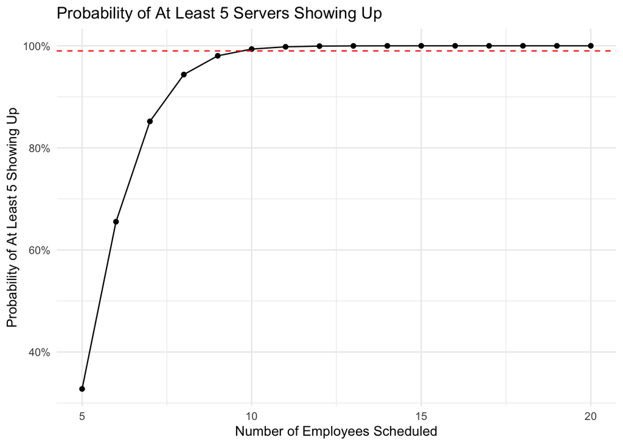

```r
library(ggplot2)

scheduled <- 5:20

cumulative_probabilities <- 1 - pbinom(4, scheduled, 4/5)

data_frame <- data.frame(Scheduled = scheduled, Probability = cumulative_probabilities)

ggplot(data_frame, aes(x = Scheduled, y = Probability)) +
  geom_line() + # Line plot
  geom_point() + # Add points to the line plot
  geom_hline(yintercept = 0.99, linetype="dashed", color = "red") + # Line for 99% confidence
  scale_y_continuous(labels = scales::percent_format()) + # Convert y-axis to percentage
  theme_minimal() +
  labs(title = "Probability of At Least 5 Servers Showing Up",
       x = "Number of Employees Scheduled",
       y = "Probability of At Least 5 Showing Up")
```